# DS 621 Fall2020: Final Project (Group3)

CO2 Emissions Regression

Zach Alexander, Sam Bellows, Donny Lofland, Joshua Registe, Neil Shah, Aaron Zalki

Source code: https://github.com/djlofland/DS621_F2020_Group3/tree/master/Final%20Project

## Methodology

### Summary Stats

| skim_type | skim_variable | n_missing | complete_rate | factor.ordered | factor.n_unique | factor.top_counts | numeric.mean | numeric.sd | numeric.p0 | numeric.p25 | numeric.p50 | numeric.p75 | numeric.p100 | numeric.hist |
| --- | --- | --- | --- | --- | --- | --- | --- | --- | --- | --- | --- | --- | --- | --- |
| factor | Make | 0 | 1 | FALSE | 42 | FOR: 628, CHE: 588, BMW: 527, MER: 419 | NA | NA | NA | NA | NA | NA | NA | NA |
| factor | Model | 0 | 1 | FALSE | 2053 | F-1: 32, F-1: 32, MUS: 27, FOC: 24 | NA | NA | NA | NA | NA | NA | NA | NA |
| factor | Vehicle.Class | 0 | 1 | FALSE | 16 | SUV: 1217, MID: 1133, COM: 1022, SUV: 735 | NA | NA | NA | NA | NA | NA | NA | NA |
| factor | Transmission | 0 | 1 | FALSE | 27 | AS6: 1324, AS8: 1211, M6: 901, A6: 789 | NA | NA | NA | NA | NA | NA | NA | NA |
| factor | Fuel.Type | 0 | 1 | FALSE | 5 | X: 3637, Z: 3202, E: 370, D: 175 | NA | NA | NA | NA | NA | NA | NA | NA |
| numeric | Engine.Size.L. | 0 | 1 | NA | NA | NA | 3.160068 | 1.354170 | 0.9 | 2.0 | 3.0 | 3.7 | 8.4 | ▇▇▃▂▁ |
| numeric | Cylinders | 0 | 1 | NA | NA | NA | 5.615030 | 1.828307 | 3.0 | 4.0 | 6.0 | 6.0 | 16.0 | ▇▇▁▁▁ |
| numeric | Fuel.Consumption.City..L.100.km. | 0 | 1 | NA | NA | NA | 12.556534 | 3.500274 | 4.2 | 10.1 | 12.1 | 14.6 | 30.6 | ▂▇▃▁▁ |
| numeric | Fuel.Consumption.Hwy..L.100.km. | 0 | 1 | NA | NA | NA | 9.041706 | 2.224456 | 4.0 | 7.5 | 8.7 | 10.2 | 20.6 | ▃▇▂▁▁ |
| numeric | Fuel.Consumption.Comb..L.100.km. | 0 | 1 | NA | NA | NA | 10.975071 | 2.892506 | 4.1 | 8.9 | 10.6 | 12.6 | 26.1 | ▃▇▂▁▁ |
| numeric | Fuel.Consumption.Comb..mpg. | 0 | 1 | NA | NA | NA | 27.481652 | 7.231879 | 11.0 | 22.0 | 27.0 | 32.0 | 69.0 | ▃▇▂▁▁ |
| numeric | CO2.Emissions.g.km. | 0 | 1 | NA | NA | NA | 250.584699 | 58.512679 | 96.0 | 208.0 | 246.0 | 288.0 | 522.0 | ▂▇▅▁▁ |

### Distributions

```
## 1 columns ignored with more than 50 categories.
## Model: 2053 categories
```

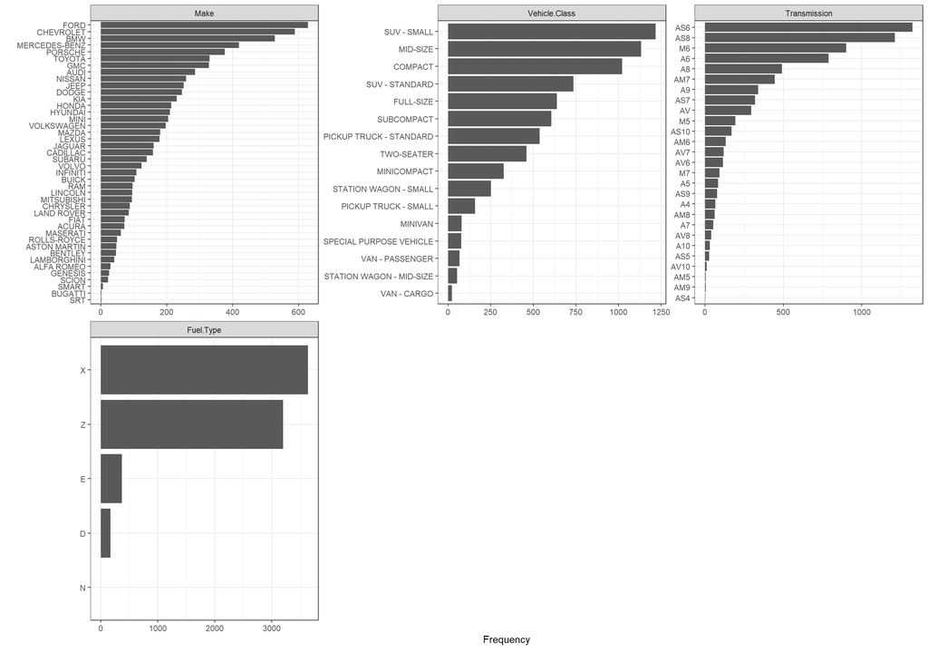

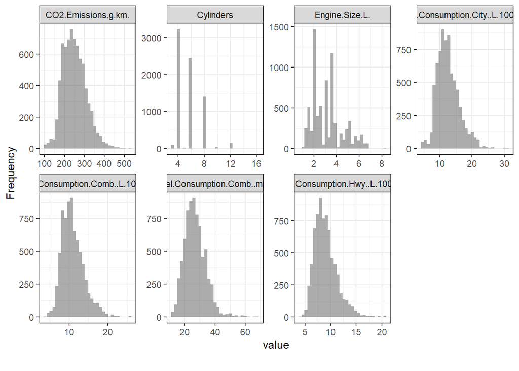

### Boxplots

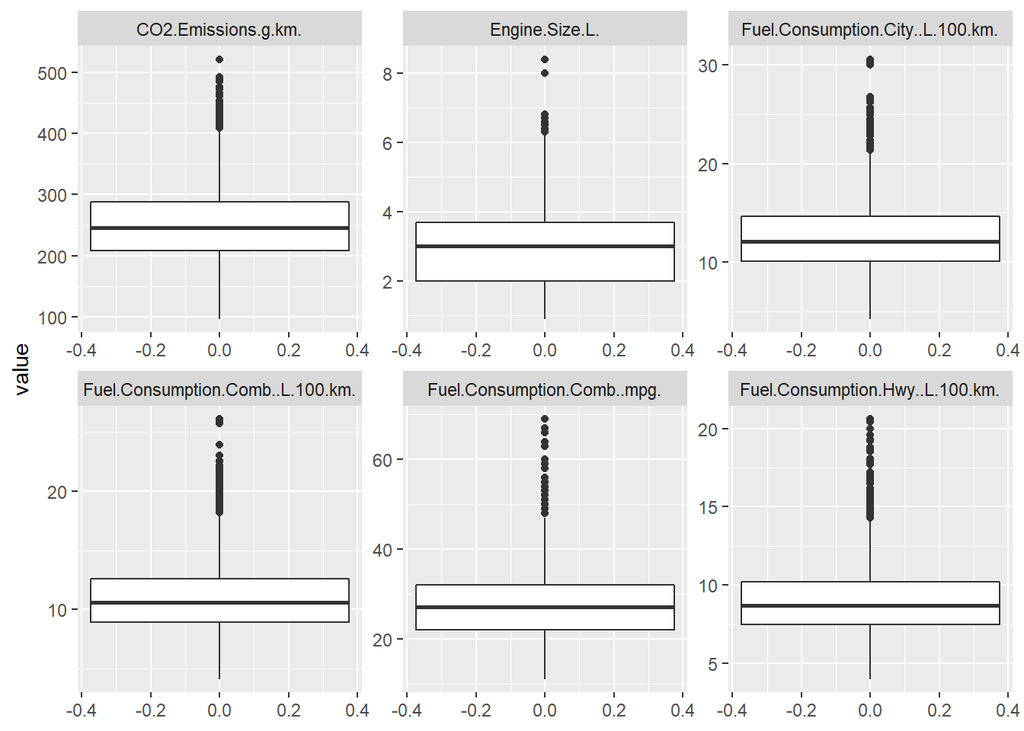

### Variable Plots

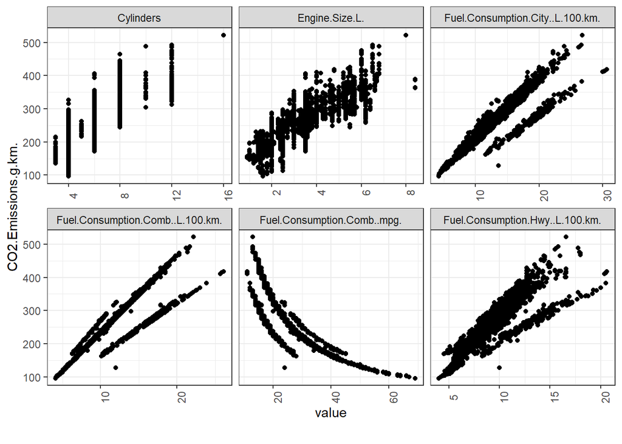

### Data Sparsity Check

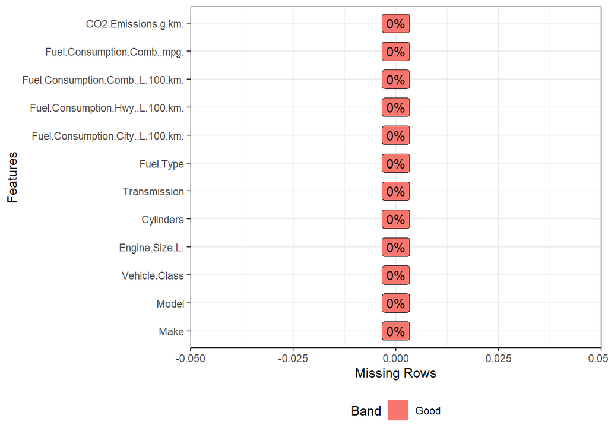

### Data Preparation

The dataset was very clean as it was taken from kaggle which usually provides quite clean datasets. We will analyze to see whether or not there is a need for outlier removal or variable transformation, but no other data preparation is required besides this.

### Removed Fields

No fields were removed, as all fields may be relevant to the target variable and no fields contain a large number of missing values.

### Near Zero Variance

|  | freqRatio | percentUnique | zeroVar | nzv |
| --- | --- | --- | --- | --- |
| Make | 1.068027 | 0.5687204 | FALSE | FALSE |
| Model | 1.000000 | 27.7995938 | FALSE | FALSE |
| Vehicle.Class | 1.074140 | 0.2166554 | FALSE | FALSE |
| Engine.Size.L. | 1.815920 | 0.6905890 | FALSE | FALSE |
| Cylinders | 1.316435 | 0.1083277 | FALSE | FALSE |
| Transmission | 1.093311 | 0.3656060 | FALSE | FALSE |
| Fuel.Type | 1.135853 | 0.0677048 | FALSE | FALSE |
| Fuel.Consumption.City..L.100.km. | 1.016260 | 2.8571429 | FALSE | FALSE |
| Fuel.Consumption.Hwy..L.100.km. | 1.135870 | 1.9363575 | FALSE | FALSE |
| Fuel.Consumption.Comb..L.100.km. | 1.066177 | 2.4509140 | FALSE | FALSE |
| Fuel.Consumption.Comb..mpg. | 1.025532 | 0.7312119 | FALSE | FALSE |
| CO2.Emissions.g.km. | 1.036585 | 4.4820582 | FALSE | FALSE |

None of the features have a near zero variance, meaning we do not need to remove any features due to lack of variance.

### Transform non-normal variables

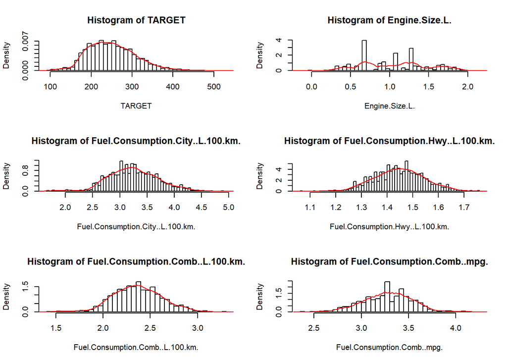

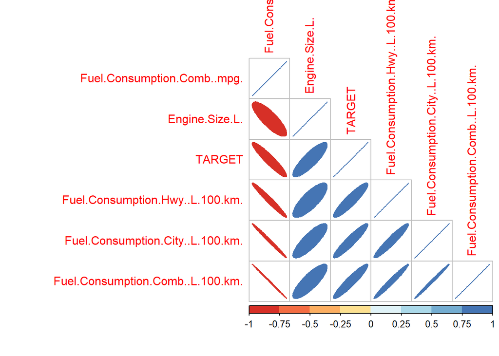

There is some strong multicollinearity between engine size and the fuel consumption features. We may need to remove one of these features when it comes time to train the model in order to assure model stability.

## Experimentation & Results

### Model 1: Exploratory, demonstrates that engine size and fuel consumption predictive of emissions

```
##
## Call:
## lm(formula = TARGET ~ ., data = temp_df)
##
## Residuals:
##      Min       1Q   Median       3Q      Max
## -129.562   -5.725    0.620    7.356  113.895
##
## Coefficients:
##                                  Estimate Std. Error t value Pr(>|t|)
## (Intercept)                       25.9585   111.0113   0.234 0.815118
## Engine.Size.L.                    34.0400     0.9632  35.342  < 2e-16 ***
## Fuel.Consumption.City..L.100.km.  57.7628    17.6298   3.276 0.001056 **
## Fuel.Consumption.Hwy..L.100.km.  157.9564    41.7178   3.786 0.000154 ***
## Fuel.Consumption.Comb..L.100.km. -36.6685    49.7358  -0.737 0.460985
## Fuel.Consumption.Comb..mpg.      -42.9553    19.5791  -2.194 0.028271 *
## ---
## Signif. codes:  0 '***' 0.001 '**' 0.01 '*' 0.05 '.' 0.1 ' ' 1
##
## Residual standard error: 19.32 on 7379 degrees of freedom
## Multiple R-squared:  0.891,  Adjusted R-squared:  0.891
## F-statistic: 1.207e+04 on 5 and 7379 DF,  p-value: < 2.2e-16
```

```
## # A tibble: 6 x 5
##   term                             estimate std.error statistic   p.value
##   <chr>                               <dbl>     <dbl>     <dbl>     <dbl>
## 1 (Intercept)                          26.0   111.        0.234 8.15e-  1
## 2 Engine.Size.L.                       34.0     0.963    35.3   6.52e-253
## 3 Fuel.Consumption.City..L.100.km.     57.8    17.6       3.28  1.06e-  3
## 4 Fuel.Consumption.Hwy..L.100.km.     158.     41.7       3.79  1.54e-  4
## 5 Fuel.Consumption.Comb..L.100.km.    -36.7    49.7      -0.737 4.61e-  1
## 6 Fuel.Consumption.Comb..mpg.         -43.0    19.6      -2.19  2.83e-  2
```

### Model 2: All features

```
##
## Call:
## lm(formula = TARGET ~ ., data = cleaneddftraining)
##
## Residuals:
##     Min      1Q  Median      3Q     Max
## -59.432  -4.469  -0.686   3.233  62.392
##
## Coefficients:
##                                         Estimate Std. Error  t value Pr(>|t|)
## (Intercept)                           -3.765e+02  4.910e+01   -7.669 2.02e-14
## Engine.Size.L.                        -9.444e+00  6.989e-01  -13.513  < 2e-16
## Fuel.Consumption.City..L.100.km.       1.286e+02  7.992e+00   16.085  < 2e-16
## Fuel.Consumption.Hwy..L.100.km.        3.094e+02  1.877e+01   16.486  < 2e-16
## Fuel.Consumption.Comb..L.100.km.      -1.062e+02  2.221e+01   -4.782 1.78e-06
## Fuel.Consumption.Comb..mpg.            8.402e+00  8.646e+00    0.972  0.33122
## Vehicle.ClassFULL-SIZE                -8.235e-01  4.664e-01   -1.766  0.07752
## Vehicle.ClassMID-SIZE                  1.147e+00  3.798e-01    3.019  0.00255
## Vehicle.ClassMINICOMPACT              -4.316e+00  6.167e-01   -6.998 2.89e-12
## Vehicle.ClassMINIVAN                  -2.841e+00  1.021e+00   -2.783  0.00540
## Vehicle.ClassPICKUP TRUCK - SMALL      4.244e+00  8.605e-01    4.932 8.38e-07
## Vehicle.ClassPICKUP TRUCK - STANDARD   3.799e+00  6.319e-01    6.011 1.95e-09
## Vehicle.ClassSPECIAL PURPOSE VEHICLE  -7.298e-01  1.068e+00   -0.683  0.49449
## Vehicle.ClassSTATION WAGON - MID-SIZE  1.758e-01  1.326e+00    0.133  0.89449
## Vehicle.ClassSTATION WAGON - SMALL    -1.254e+00  6.177e-01   -2.030  0.04244
## Vehicle.ClassSUBCOMPACT               -1.963e+00  4.440e-01   -4.421 1.00e-05
## Vehicle.ClassSUV - SMALL              -1.787e+00  4.404e-01   -4.057 5.04e-05
## Vehicle.ClassSUV - STANDARD            4.533e+00  5.327e-01    8.509  < 2e-16
## Vehicle.ClassTWO-SEATER                1.424e+00  5.149e-01    2.766  0.00569
## Vehicle.ClassVAN - CARGO               1.925e+01  2.178e+00    8.839  < 2e-16
## Vehicle.ClassVAN - PASSENGER           3.307e+01  1.198e+00   27.618  < 2e-16
## Cylinders                              5.284e+00  1.484e-01   35.597  < 2e-16
## TransmissionA4                        -3.566e+00  2.030e+00   -1.757  0.07901
## TransmissionA5                         1.992e+00  1.821e+00    1.094  0.27407
## TransmissionA6                        -1.250e+00  1.552e+00   -0.805  0.42083
## TransmissionA7                         1.654e+00  1.901e+00    0.870  0.38437
## TransmissionA8                        -2.586e+00  1.558e+00   -1.660  0.09697
## TransmissionA9                        -2.058e+00  1.602e+00   -1.284  0.19906
## TransmissionAM5                        9.832e+00  4.140e+00    2.375  0.01759
## TransmissionAM6                        7.944e+00  1.721e+00    4.617 3.98e-06
```

[output cut: 66 more lines]

```
## TransmissionAV7
## TransmissionAV8
## TransmissionM5
## TransmissionM6
## TransmissionM7
## Fuel.TypeE                            ***
## Fuel.TypeN                            ***
## Fuel.TypeX                            ***
## Fuel.TypeZ                            ***
## ---
## Signif. codes:  0 '***' 0.001 '**' 0.01 '*' 0.05 '.' 0.1 ' ' 1
##
## Residual standard error: 7.577 on 5856 degrees of freedom
## Multiple R-squared:  0.9835, Adjusted R-squared:  0.9833
## F-statistic:  6830 on 51 and 5856 DF,  p-value: < 2.2e-16
```

### Model 3: Only significant features

```
##
## Call:
## lm(formula = TARGET ~ Engine.Size.L. + Fuel.Consumption.City..L.100.km. +
##     Fuel.Consumption.Hwy..L.100.km. + Fuel.Consumption.Comb..L.100.km. +
##     Vehicle.Class + Cylinders + Transmission + Fuel.Type, data = cleaneddftraining)
##
## Residuals:
##     Min      1Q  Median      3Q     Max
## -59.271  -4.441  -0.677   3.215  62.337
##
## Coefficients:
##                                         Estimate Std. Error  t value Pr(>|t|)
## (Intercept)                           -329.07556    5.12561  -64.202  < 2e-16
## Engine.Size.L.                          -9.44859    0.69887  -13.520  < 2e-16
## Fuel.Consumption.City..L.100.km.       128.39457    7.99040   16.069  < 2e-16
## Fuel.Consumption.Hwy..L.100.km.        309.09482   18.76647   16.471  < 2e-16
## Fuel.Consumption.Comb..L.100.km.      -114.20553   20.63426   -5.535 3.25e-08
## Vehicle.ClassFULL-SIZE                  -0.82073    0.46643   -1.760  0.07853
## Vehicle.ClassMID-SIZE                    1.14888    0.37979    3.025  0.00250
## Vehicle.ClassMINICOMPACT                -4.29099    0.61617   -6.964 3.67e-12
## Vehicle.ClassMINIVAN                    -2.79274    1.01939   -2.740  0.00617
## Vehicle.ClassPICKUP TRUCK - SMALL        4.24419    0.86050    4.932 8.35e-07
## Vehicle.ClassPICKUP TRUCK - STANDARD     3.81366    0.63175    6.037 1.67e-09
## Vehicle.ClassSPECIAL PURPOSE VEHICLE    -0.73794    1.06813   -0.691  0.48967
## Vehicle.ClassSTATION WAGON - MID-SIZE    0.15185    1.32546    0.115  0.90880
## Vehicle.ClassSTATION WAGON - SMALL      -1.26218    0.61760   -2.044  0.04103
## Vehicle.ClassSUBCOMPACT                 -1.95578    0.44398   -4.405 1.08e-05
## Vehicle.ClassSUV - SMALL                -1.79416    0.44037   -4.074 4.68e-05
## Vehicle.ClassSUV - STANDARD              4.53089    0.53267    8.506  < 2e-16
## Vehicle.ClassTWO-SEATER                  1.44246    0.51453    2.803  0.00507
## Vehicle.ClassVAN - CARGO                19.29205    2.17718    8.861  < 2e-16
## Vehicle.ClassVAN - PASSENGER            33.08481    1.19746   27.629  < 2e-16
## Cylinders                                5.28431    0.14845   35.597  < 2e-16
## TransmissionA4                          -3.58813    2.02958   -1.768  0.07713
## TransmissionA5                           2.02738    1.82063    1.114  0.26552
## TransmissionA6                          -1.21678    1.55206   -0.784  0.43309
## TransmissionA7                           1.70900    1.90063    0.899  0.36860
## TransmissionA8                          -2.55674    1.55737   -1.642  0.10071
## TransmissionA9                          -2.00683    1.60134   -1.253  0.21018
## TransmissionAM5                          9.79679    4.13985    2.366  0.01799
```

[output cut: 66 more lines]

```
## TransmissionAV7
## TransmissionAV8
## TransmissionM5
## TransmissionM6
## TransmissionM7
## Fuel.TypeE                            ***
## Fuel.TypeN                            ***
## Fuel.TypeX                            ***
## Fuel.TypeZ                            ***
## ---
## Signif. codes:  0 '***' 0.001 '**' 0.01 '*' 0.05 '.' 0.1 ' ' 1
##
## Residual standard error: 7.577 on 5857 degrees of freedom
## Multiple R-squared:  0.9835, Adjusted R-squared:  0.9833
## F-statistic:  6967 on 50 and 5857 DF,  p-value: < 2.2e-16
```

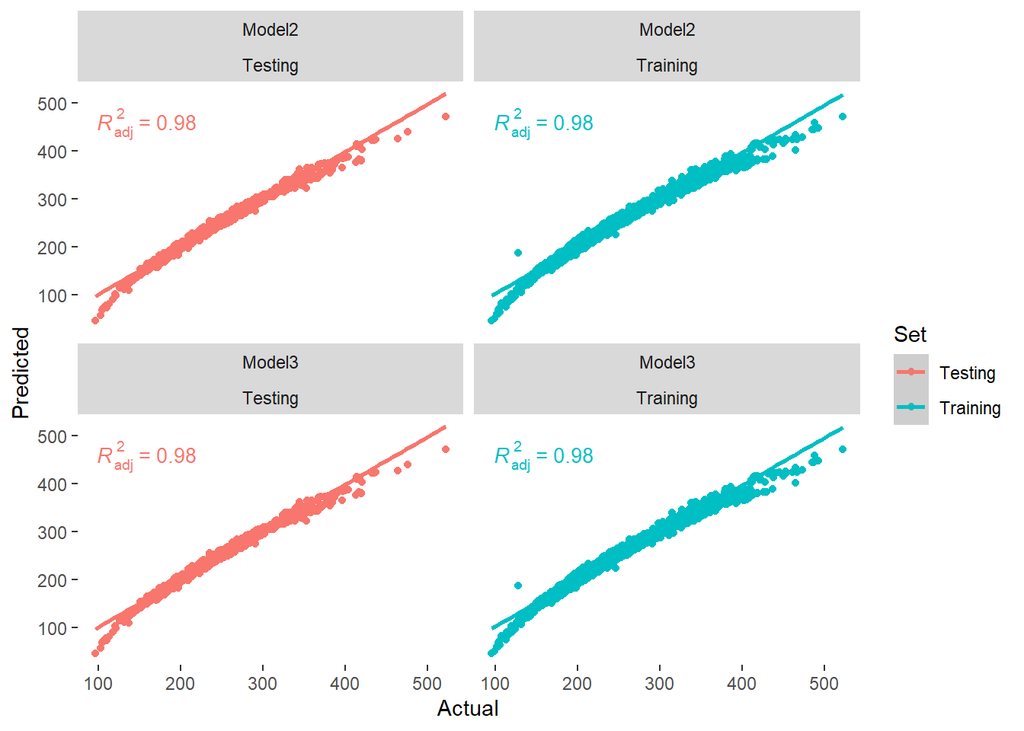

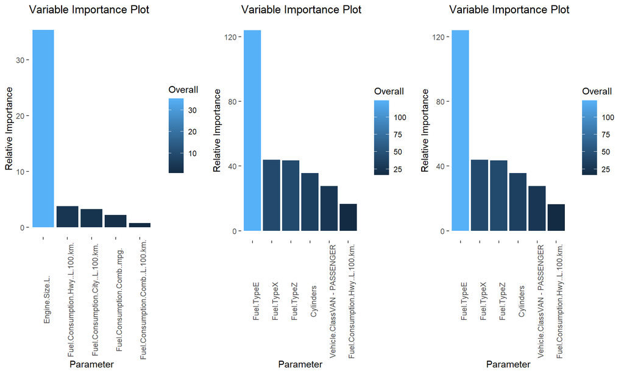

## Conclusion

We will select Model 3 as our emissions model, as it has the same performance as model 2 with fewer features, reducing the complexity of the regression problem. We will use this model to estimate the total emissions in the state of CA caused by vehicles with internal combusion engines to better understand the magnitude of the effect the ban on these engines will have on overall emissions. In order to do this, we will be using CA car registration data from here: https://www.cncda.org/wp-content/uploads/Cal-Covering-4Q-18.pdf

| Make | avg_emissions | Count | Total |
| --- | --- | --- | --- |
| acura | 224.4964 | 23231 | 5215276.4 |
| alfa romeo | 226.7318 | 5024 | 1139100.6 |
| audi | 254.2433 | 42493 | 10803558.5 |
| bmw | 256.0242 | 70747 | 18112947.3 |
| buick | 234.8843 | 9293 | 2182780.2 |
| cadillac | 266.0464 | 11621 | 3091724.7 |
| chevrolet | 263.8729 | 157160 | 41470264.7 |
| chrysler | 247.5269 | 14446 | 3575774.2 |
| dodge | 275.8251 | 33557 | 9255863.8 |
| fiat | 192.1904 | 2792 | 536595.7 |
| ford | 261.2009 | 176315 | 46053640.8 |
| genesis | 281.5222 | 2091 | 588662.9 |
| gmc | 300.3317 | 34447 | 10345527.4 |
| honda | 190.2134 | 247635 | 47103487.0 |
| hyundai | 205.6270 | 59544 | 12243856.9 |
| infiniti | 255.2124 | 18699 | 4772217.4 |
| jaguar | 269.6314 | 5221 | 1407745.6 |
| jeep | 249.0715 | 65740 | 16373961.4 |
| kia | 211.8869 | 65160 | 13806549.4 |
| land rover | 286.7372 | 17748 | 5089012.4 |
| lexus | 242.9448 | 62570 | 15201058.4 |
| lincoln | 266.3294 | 6816 | 1815301.4 |
| maserati | 312.4427 | 2396 | 748612.6 |
| mazda | 191.1281 | 46683 | 8922431.6 |
| mini | 194.8417 | 8941 | 1742080.1 |
| mitsubishi | 201.3461 | 8135 | 1637950.4 |
| nissan | 239.8084 | 126229 | 30270779.3 |
| porsche | 261.3733 | 13469 | 3520436.5 |
| ram | 292.3715 | 39439 | 11530839.3 |
| subaru | 217.9003 | 77799 | 16952428.7 |
| toyota | 221.2393 | 334915 | 74096358.7 |
| volkswagen | 210.5246 | 45219 | 9519714.1 |
| volvo | 231.6343 | 12057 | 2792814.6 |

```
## [1] 431919353
```

We get a sum total of approximately 432,000,000 grams per km the average vehicle operator drives in CA. Given the Federal Highway Administration estimates that the average driver in the United States drives 13,500 miles per year or 21,726 km, we can estimate that per year, internal combustion engines release 9,386,000,000,000 grams per year, or 20,649,580,500 pounds of CO2 emissions per year. This is an enormous amount of CO2 emissions, and cutting into this will only benefit the CA and world environment.